# Project: Concrete Strength Prediction

#### water_binder_ratio

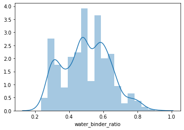

```python
sns.distplot(df["water_binder_ratio"])
plt.show()
```

We can 2 or 3 gaussians here.

```python
GMM_(2,"water_binder_ratio")
```

```
water_binder_ratio       -0.651804
water_binder_ratio_gmm   -0.505151
strength                  1.000000
Name: strength, dtype: float64
==========================================================
	Correlation between **water_binder_ratio_gmm** and **strength** is lower than between **water_binder_ratio** and
        **strength** so the created clusters might not be useful here
```

```python
GMM_(3,"water_binder_ratio")
```

```
water_binder_ratio       -0.651804
water_binder_ratio_gmm    0.275383
strength                  1.000000
Name: strength, dtype: float64
==========================================================
	Correlation between **water_binder_ratio_gmm** and **strength** is lower than between **water_binder_ratio** and
        **strength** so the created clusters might not be useful here
```

#### ln_age

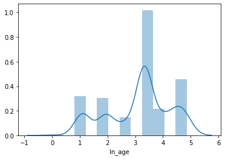

```python
sns.distplot(df["ln_age"])
plt.show()
```

We can see 4 gaussians here.

```python
GMM_(4,"ln_age")
```

```
ln_age        0.568469
ln_age_gmm   -0.058029
strength      1.000000
Name: strength, dtype: float64
==========================================================
	Correlation between **ln_age_gmm** and **strength** is lower than between **ln_age** and
        **strength** so the created clusters might not be useful here
```

```python
df.head()
```

|  | cement | slag | ash | water | superplastic | coarseagg | fineagg | age | strength | water_binder_ratio | ln_age | slag_gmm | water_gmm |
| --- | --- | --- | --- | --- | --- | --- | --- | --- | --- | --- | --- | --- | --- |
| 0 | 141.3 | 212.0 | 0.0 | 203.5 | 0.0 | 971.8 | 748.5 | 28.0 | 29.89 | 0.575998 | 3.332205 | 1 | 0 |
| 1 | 168.9 | 42.2 | 124.3 | 158.3 | 10.8 | 1080.8 | 796.2 | 14.0 | 23.51 | 0.554116 | 2.639057 | 1 | 2 |
| 2 | 250.0 | 0.0 | 95.7 | 187.4 | 5.5 | 956.9 | 861.2 | 28.0 | 29.22 | 0.609589 | 3.332205 | 0 | 0 |
| 3 | 266.0 | 114.0 | 0.0 | 228.0 | 0.0 | 932.0 | 670.0 | 28.0 | 45.85 | 0.600000 | 3.332205 | 1 | 3 |
| 4 | 154.8 | 183.4 | 0.0 | 193.3 | 9.1 | 1047.4 | 696.7 | 28.0 | 18.29 | 0.571555 | 3.332205 | 1 | 0 |

### Conclusion

We can see that we have taken forward clusters for slag and water

# Creating the Model and Tuning It

### Decision Tree Regressor

Let's first scale the values.

```python
scaler = MinMaxScaler()

df[df.columns] = scaler.fit_transform(df[df.columns])
```

```python
df.head()
```

|  | cement | slag | ash | water | superplastic | coarseagg | fineagg | age | strength | water_binder_ratio | ln_age | slag_gmm | water_gmm |
| --- | --- | --- | --- | --- | --- | --- | --- | --- | --- | --- | --- | --- | --- |
| 0 | 0.089726 | 0.593214 | 0.000000 | 0.731089 | 0.000000 | 0.496512 | 0.418048 | 0.210117 | 0.343341 | 0.512725 | 0.685120 | 1.0 | 0.000000 |
| 1 | 0.152740 | 0.118083 | 0.621189 | 0.314114 | 0.423529 | 0.813372 | 0.547115 | 0.101167 | 0.263859 | 0.479817 | 0.542605 | 1.0 | 0.666667 |
| 2 | 0.337900 | 0.000000 | 0.478261 | 0.582565 | 0.215686 | 0.453198 | 0.722993 | 0.210117 | 0.334994 | 0.563244 | 0.685120 | 0.0 | 0.000000 |
| 3 | 0.374429 | 0.318993 | 0.000000 | 0.957103 | 0.000000 | 0.380814 | 0.205642 | 0.210117 | 0.542170 | 0.548822 | 0.685120 | 1.0 | 1.000000 |
| 4 | 0.120548 | 0.513186 | 0.000000 | 0.636993 | 0.356863 | 0.716279 | 0.277887 | 0.210117 | 0.198829 | 0.506044 | 0.685120 | 1.0 | 0.000000 |

```python
X = df[['slag','cement', 'ash', 'water', 'superplastic', 'coarseagg', 'fineagg', 'age',
       'water_binder_ratio', 'ln_age', 'slag_gmm', 'water_gmm']]
y = df["strength"]
```

```python
X.head()
```

|  | slag | cement | ash | water | superplastic | coarseagg | fineagg | age | water_binder_ratio | ln_age | slag_gmm | water_gmm |
| --- | --- | --- | --- | --- | --- | --- | --- | --- | --- | --- | --- | --- |
| 0 | 0.593214 | 0.089726 | 0.000000 | 0.731089 | 0.000000 | 0.496512 | 0.418048 | 0.210117 | 0.512725 | 0.685120 | 1.0 | 0.000000 |
| 1 | 0.118083 | 0.152740 | 0.621189 | 0.314114 | 0.423529 | 0.813372 | 0.547115 | 0.101167 | 0.479817 | 0.542605 | 1.0 | 0.666667 |
| 2 | 0.000000 | 0.337900 | 0.478261 | 0.582565 | 0.215686 | 0.453198 | 0.722993 | 0.210117 | 0.563244 | 0.685120 | 0.0 | 0.000000 |
| 3 | 0.318993 | 0.374429 | 0.000000 | 0.957103 | 0.000000 | 0.380814 | 0.205642 | 0.210117 | 0.548822 | 0.685120 | 1.0 | 1.000000 |
| 4 | 0.513186 | 0.120548 | 0.000000 | 0.636993 | 0.356863 | 0.716279 | 0.277887 | 0.210117 | 0.506044 | 0.685120 | 1.0 | 0.000000 |

```python
y.head()
```

```
0    0.343341
1    0.263859
2    0.334994
3    0.542170
4    0.198829
Name: strength, dtype: float64
```

```python
# Split X and y into training and test set in 70:30 ratio
X_train, X_test, y_train, y_test = train_test_split(X,y, test_size = 0.3, random_state = 1)
```

```python
dt = DecisionTreeRegressor()
```

```python
dt.fit(X_train,y_train)
```

```
DecisionTreeRegressor()
```

```python
print('Feature importances: \n',pd.DataFrame(dt.feature_importances_,columns=['Imp'],index=X_train.columns))
```

```
Feature importances:
                          Imp
slag                0.011065
cement              0.045145
ash                 0.006079
water               0.028132
superplastic        0.021204
coarseagg           0.012636
fineagg             0.013728
age                 0.364294
water_binder_ratio  0.468625
ln_age              0.026487
slag_gmm            0.000417
water_gmm           0.002190
```

### Tuning the Model

[output not shown]

```python
y_pred = dt.predict(X_test)
# performance on train data
print('Performance on training data using DT:',dt.score(X_train,y_train))
# performance on test data
print('Performance on testing data using DT:',dt.score(X_test,y_test))
#Evaluate the model using accuracy
acc_DT=metrics.r2_score(y_test, y_pred)
print('Accuracy DT: ',acc_DT)
```

```
Performance on training data using DT: 0.9946752996414926
Performance on testing data using DT: 0.8380503050807623
Accuracy DT:  0.8380503050807623
```

There is a overfitting in the model as the dataset is performing 99.47% accurately in trainnig data. However, the accuracy on test data drops (84%).

To create a summary, we will keep on storing these results in a dataframe.

```python
#Store the accuracy results for each model in a dataframe for final comparison
results = pd.DataFrame({'Method':['Decision Tree'], 'accuracy': acc_DT},index={'1'})
results = results[['Method', 'accuracy']]
results
```

|  | Method | accuracy |
| --- | --- | --- |
| 1 | Decision Tree | 0.83805 |

For each model, we will also carry out K Fold Cross Validation.

```python
kfold = KFold(n_splits=10, random_state=42)
results1 = cross_val_score(dt,X, y, cv=kfold)
accuracy=np.mean(abs(results1))
print('Average accuracy: ',accuracy)
print('Standard Deviation: ',results1.std())
```

```
Average accuracy:  0.878651812224484
Standard Deviation:  0.029952298304019236
```

```python
#Store the accuracy results for each model in a dataframe for final comparison
tempResultsDf = pd.DataFrame({'Method':['Decision Tree k fold'], 'accuracy': [accuracy]},index={'2'})
results = pd.concat([results, tempResultsDf])
results = results[['Method', 'accuracy']]
results
```

|  | Method | accuracy |
| --- | --- | --- |
| 1 | Decision Tree | 0.838050 |
| 2 | Decision Tree k fold | 0.878652 |

Let's now try using only the top few features and see how the model performs.

```python
X = df.drop(['slag_gmm','water_gmm','ash','slag','strength'],axis=1)
y = df['strength']
```

```python
# Split X and y into training and test set in 70:30 ratio
X_train, X_test, y_train, y_test = train_test_split(X,y, test_size = 0.3, random_state = 1)
```

```python
dt = DecisionTreeRegressor()
dt.fit(X_train , y_train)
```

```
DecisionTreeRegressor()
```

```python
y_pred = dt.predict(X_test)
# performance on train data
print('Performance on training data using DT:',dt.score(X_train,y_train))
# performance on test data
print('Performance on testing data using DT:',dt.score(X_test,y_test))
#Evaluate the model using accuracy
acc_DT=metrics.r2_score(y_test, y_pred)
print('Accuracy DT: ',acc_DT)
```

```
Performance on training data using DT: 0.9946752996414926
Performance on testing data using DT: 0.8397381749183972
Accuracy DT:  0.8397381749183972
```

```python
#Store the accuracy results for each model in a dataframe for final comparison
tempResultsDf = pd.DataFrame({'Method':['Decision Tree 2'], 'accuracy': [acc_DT]},index={'3'})
results = pd.concat([results, tempResultsDf])
results = results[['Method', 'accuracy']]
results
```

|  | Method | accuracy |
| --- | --- | --- |
| 1 | Decision Tree | 0.838050 |
| 2 | Decision Tree k fold | 0.878652 |
| 3 | Decision Tree 2 | 0.839738 |

Let's try to regularize/prune the decision tree to make it simpler.

```python
# Regularizing the Decision tree classifier and fitting the model
reg_dt_model = DecisionTreeRegressor( max_depth = 4,random_state=1,min_samples_leaf=5)
reg_dt_model.fit(X_train, y_train)
```

```
DecisionTreeRegressor(max_depth=4, min_samples_leaf=5, random_state=1)
```

```python
y_pred = reg_dt_model.predict(X_test)
# performance on train data
print('Performance on training data using DT:',reg_dt_model.score(X_train,y_train))
# performance on test data
print('Performance on testing data using DT:',reg_dt_model.score(X_test,y_test))
#Evaluate the model using accuracy
acc_RDT=metrics.r2_score(y_test, y_pred)
print('Accuracy DT: ',acc_RDT)
```

```
Performance on training data using DT: 0.8178753446383492
Performance on testing data using DT: 0.7899643208098955
Accuracy DT:  0.7899643208098955
```

Not only is this model simple, but is also not overfitting the training datase (the difference in accuracies is just 2%)

```python
#Store the accuracy results for each model in a dataframe for final comparison
tempResultsDf = pd.DataFrame({'Method':['Pruned Decision Tree'], 'accuracy': [acc_RDT]},index={'4'})
results = pd.concat([results, tempResultsDf])
results = results[['Method', 'accuracy']]
results
```

|  | Method | accuracy |
| --- | --- | --- |
| 1 | Decision Tree | 0.838050 |
| 2 | Decision Tree k fold | 0.878652 |
| 3 | Decision Tree 2 | 0.839738 |
| 4 | Pruned Decision Tree | 0.789964 |

Let's now carry K-Fold CV.

```python
kfold = KFold(n_splits=10, random_state=42)
results1 = cross_val_score(reg_dt_model,X, y, cv=kfold)
accuracy=np.mean(abs(results1))
print('Average accuracy: ',accuracy)
print('Standard Deviation: ',results1.std())
```

```
Average accuracy:  0.7786376694253806
Standard Deviation:  0.042795625921230825
```

```python
#Store the accuracy results for each model in a dataframe for final comparison
tempResultsDf = pd.DataFrame({'Method':['Pruned Decision Tree k fold'], 'accuracy': [accuracy]},index={'5'})
results = pd.concat([results, tempResultsDf])
results = results[['Method', 'accuracy']]
results
```

|  | Method | accuracy |
| --- | --- | --- |
| 1 | Decision Tree | 0.838050 |
| 2 | Decision Tree k fold | 0.878652 |
| 3 | Decision Tree 2 | 0.839738 |
| 4 | Pruned Decision Tree | 0.789964 |
| 5 | Pruned Decision Tree k fold | 0.778638 |

Now that we have tried different Decision Tree variations, let's now try ensemble techniques - Random Forest Regressor.

### Random Forest Regressor

```python
X = df.drop("strength",axis=1)
y = df["strength"]
```

```python
# Split X and y into training and test set in 70:30 ratio
X_train, X_test, y_train, y_test = train_test_split(X,y, test_size = 0.3, random_state = 1)
```

```python
model=RandomForestRegressor()
model.fit(X_train, y_train)
```

```
RandomForestRegressor()
```

```python
# performance on train data
print('Performance on training data using RFR:',model.score(X_train,y_train))
# performance on test data
print('Performance on testing data using RFR:',model.score(X_test,y_test))
#Evaluate the model using accuracy
acc_RFR=metrics.r2_score(y_test, y_pred)
print('Accuracy DT: ',acc_RFR)
```

```
Performance on training data using RFR: 0.9831984477581298
Performance on testing data using RFR: 0.9074997003464359
Accuracy DT:  0.7899643208098955
```

The difference in the training and testing data accuracy shows that there is overfitting.

```python
#Store the accuracy results for each model in a dataframe for final comparison
tempResultsDf = pd.DataFrame({'Method':['Random Forest Regressor'], 'accuracy': [acc_RFR]},index={'6'})
results = pd.concat([results, tempResultsDf])
results = results[['Method', 'accuracy']]
results
```

|  | Method | accuracy |
| --- | --- | --- |
| 1 | Decision Tree | 0.838050 |
| 2 | Decision Tree k fold | 0.878652 |
| 3 | Decision Tree 2 | 0.839738 |
| 4 | Pruned Decision Tree | 0.789964 |
| 5 | Pruned Decision Tree k fold | 0.778638 |
| 6 | Random Forest Regressor | 0.789964 |

Let's now perform k-fold CV.

```python
kfold = KFold(n_splits=10, random_state=1)
results1 = cross_val_score(model,X, y, cv=kfold)
accuracy=np.mean(abs(results1))
print('Average accuracy: ',accuracy)
print('Standard Deviation: ',results1.std())
```

```
Average accuracy:  0.9192929845294773
Standard Deviation:  0.024596693752584928
```

```python
#Store the accuracy results for each model in a dataframe for final comparison
tempResultsDf = pd.DataFrame({'Method':['Random Forest Regressor k fold'], 'accuracy': [accuracy]},index={'7'})
results = pd.concat([results, tempResultsDf])
results = results[['Method', 'accuracy']]
results
```

|  | Method | accuracy |
| --- | --- | --- |
| 1 | Decision Tree | 0.838050 |
| 2 | Decision Tree k fold | 0.878652 |
| 3 | Decision Tree 2 | 0.839738 |
| 4 | Pruned Decision Tree | 0.789964 |
| 5 | Pruned Decision Tree k fold | 0.778638 |
| 6 | Random Forest Regressor | 0.789964 |
| 7 | Random Forest Regressor k fold | 0.919293 |

### Gradient Boosting Regressor

```python
model=GradientBoostingRegressor()
model.fit(X_train, y_train)
```

```
GradientBoostingRegressor()
```

```python
y_pred = model.predict(X_test)
# performance on train data
print('Performance on training data using GBR:',model.score(X_train,y_train))
# performance on test data
print('Performance on testing data using GBR:',model.score(X_test,y_test))
#Evaluate the model using accuracy
acc_GBR=metrics.r2_score(y_test, y_pred)
print('Accuracy DT: ',acc_GBR)
```

```
Performance on training data using GBR: 0.9544180572246411
Performance on testing data using GBR: 0.9138609455248772
Accuracy DT:  0.9138609455248772
```

```python
#Store the accuracy results for each model in a dataframe for final comparison
tempResultsDf = pd.DataFrame({'Method':['Gradient Boost Regressor'], 'accuracy': [acc_GBR]},index={'8'})
results = pd.concat([results, tempResultsDf])
results = results[['Method', 'accuracy']]
results
```

|  | Method | accuracy |
| --- | --- | --- |
| 1 | Decision Tree | 0.838050 |
| 2 | Decision Tree k fold | 0.878652 |
| 3 | Decision Tree 2 | 0.839738 |
| 4 | Pruned Decision Tree | 0.789964 |
| 5 | Pruned Decision Tree k fold | 0.778638 |
| 6 | Random Forest Regressor | 0.789964 |
| 7 | Random Forest Regressor k fold | 0.919293 |
| 8 | Gradient Boost Regressor | 0.913861 |

There is an improvement in accuracy but let's check k fold performance.

```python
kfold = KFold(n_splits=10, random_state=1)
results1 = cross_val_score(model,X, y, cv=kfold)
accuracy=np.mean(abs(results1))
print('Average accuracy: ',accuracy)
print('Standard Deviation: ',results1.std())
```

```
Average accuracy:  0.9148663772481452
Standard Deviation:  0.020378212359274672
```

```python
#Store the accuracy results for each model in a dataframe for final comparison
tempResultsDf = pd.DataFrame({'Method':['Gradient Boost Regressor k fold'], 'accuracy': [accuracy]},index={'9'})
results = pd.concat([results, tempResultsDf])
results = results[['Method', 'accuracy']]
results
```

|  | Method | accuracy |
| --- | --- | --- |
| 1 | Decision Tree | 0.838050 |
| 2 | Decision Tree k fold | 0.878652 |
| 3 | Decision Tree 2 | 0.839738 |
| 4 | Pruned Decision Tree | 0.789964 |
| 5 | Pruned Decision Tree k fold | 0.778638 |
| 6 | Random Forest Regressor | 0.789964 |
| 7 | Random Forest Regressor k fold | 0.919293 |
| 8 | Gradient Boost Regressor | 0.913861 |
| 9 | Gradient Boost Regressor k fold | 0.914866 |

### Ada Boosting Regressor

```python
model=AdaBoostRegressor()
model.fit(X_train, y_train)
```

```
AdaBoostRegressor()
```

```python
y_pred = model.predict(X_test)
# performance on train data
print('Performance on training data using GBR:',model.score(X_train,y_train))
# performance on test data
print('Performance on testing data using GBR:',model.score(X_test,y_test))
#Evaluate the model using accuracy
acc_ABR=metrics.r2_score(y_test, y_pred)
print('Accuracy DT: ',acc_ABR)
print('MSE: ',metrics.mean_squared_error(y_test, y_pred))
```

```
Performance on training data using GBR: 0.8561233708094984
Performance on testing data using GBR: 0.8129647142879406
Accuracy DT:  0.8129647142879406
MSE:  0.008448294510713238
```

```python
#Store the accuracy results for each model in a dataframe for final comparison
tempResultsDf = pd.DataFrame({'Method':['Ada Boosting Regressor'], 'accuracy': [acc_ABR]},index={'10'})
results = pd.concat([results, tempResultsDf])
results = results[['Method', 'accuracy']]
results
```

|  | Method | accuracy |
| --- | --- | --- |
| 1 | Decision Tree | 0.838050 |
| 2 | Decision Tree k fold | 0.878652 |
| 3 | Decision Tree 2 | 0.839738 |
| 4 | Pruned Decision Tree | 0.789964 |
| 5 | Pruned Decision Tree k fold | 0.778638 |
| 6 | Random Forest Regressor | 0.789964 |
| 7 | Random Forest Regressor k fold | 0.919293 |
| 8 | Gradient Boost Regressor | 0.913861 |
| 9 | Gradient Boost Regressor k fold | 0.914866 |
| 10 | Ada Boosting Regressor | 0.812965 |

With ada boosting, the accuracy has decreased significantly.

```python
kfold = KFold(n_splits=10, random_state=1)
results1 = cross_val_score(model,X, y, cv=kfold)
accuracy=np.mean(abs(results1))
print('Average accuracy: ',accuracy)
print('Standard Deviation: ',results1.std())
```

```
Average accuracy:  0.8248051059938082
Standard Deviation:  0.0257492260228025
```

```python
#Store the accuracy results for each model in a dataframe for final comparison
tempResultsDf = pd.DataFrame({'Method':['Ada Boosting Regressor k fold'], 'accuracy': [accuracy]},index={'11'})
results = pd.concat([results, tempResultsDf])
results = results[['Method', 'accuracy']]
results
```

|  | Method | accuracy |
| --- | --- | --- |
| 1 | Decision Tree | 0.838050 |
| 2 | Decision Tree k fold | 0.878652 |
| 3 | Decision Tree 2 | 0.839738 |
| 4 | Pruned Decision Tree | 0.789964 |
| 5 | Pruned Decision Tree k fold | 0.778638 |
| 6 | Random Forest Regressor | 0.789964 |
| 7 | Random Forest Regressor k fold | 0.919293 |
| 8 | Gradient Boost Regressor | 0.913861 |
| 9 | Gradient Boost Regressor k fold | 0.914866 |
| 10 | Ada Boosting Regressor | 0.812965 |
| 11 | Ada Boosting Regressor k fold | 0.824805 |

### Bagging Regressor

```python
model=BaggingRegressor()
model.fit(X_train, y_train)
```

```
BaggingRegressor()
```

```python
y_pred = model.predict(X_test)
# performance on train data
print('Performance on training data using Bagging Regressor:',model.score(X_train,y_train))
# performance on test data
print('Performance on testing data using Bagging Regressor:',model.score(X_test,y_test))
#Evaluate the model using accuracy
acc_BR=metrics.r2_score(y_test, y_pred)
print('Accuracy DT: ',acc_BR)
```

```
Performance on training data using Bagging Regressor: 0.9786586281973815
Performance on testing data using Bagging Regressor: 0.9029959304806033
Accuracy DT:  0.9029959304806033
```

```python
#Store the accuracy results for each model in a dataframe for final comparison
tempResultsDf = pd.DataFrame({'Method':['Bagging Regressor'], 'accuracy': [acc_BR]},index={'12'})
results = pd.concat([results, tempResultsDf])
results = results[['Method', 'accuracy']]
results
```

|  | Method | accuracy |
| --- | --- | --- |
| 1 | Decision Tree | 0.838050 |
| 2 | Decision Tree k fold | 0.878652 |
| 3 | Decision Tree 2 | 0.839738 |
| 4 | Pruned Decision Tree | 0.789964 |
| 5 | Pruned Decision Tree k fold | 0.778638 |
| 6 | Random Forest Regressor | 0.789964 |
| 7 | Random Forest Regressor k fold | 0.919293 |
| 8 | Gradient Boost Regressor | 0.913861 |
| 9 | Gradient Boost Regressor k fold | 0.914866 |
| 10 | Ada Boosting Regressor | 0.812965 |
| 11 | Ada Boosting Regressor k fold | 0.824805 |
| 12 | Bagging Regressor | 0.902996 |

```python
kfold = KFold(n_splits=10, random_state=1)
results1 = cross_val_score(model,X, y, cv=kfold)
accuracy=np.mean(abs(results1))
print('Average accuracy: ',accuracy)
print('Standard Deviation: ',results1.std())
```

```
Average accuracy:  0.9149416495433759
Standard Deviation:  0.026812894702353995
```

```python
#Store the accuracy results for each model in a dataframe for final comparison
tempResultsDf = pd.DataFrame({'Method':['Bagging Regressor k fold'], 'accuracy': [accuracy]},index={'13'})
results = pd.concat([results, tempResultsDf])
results = results[['Method', 'accuracy']]
results
```

|  | Method | accuracy |
| --- | --- | --- |
| 1 | Decision Tree | 0.838050 |
| 2 | Decision Tree k fold | 0.878652 |
| 3 | Decision Tree 2 | 0.839738 |
| 4 | Pruned Decision Tree | 0.789964 |
| 5 | Pruned Decision Tree k fold | 0.778638 |
| 6 | Random Forest Regressor | 0.789964 |
| 7 | Random Forest Regressor k fold | 0.919293 |
| 8 | Gradient Boost Regressor | 0.913861 |
| 9 | Gradient Boost Regressor k fold | 0.914866 |
| 10 | Ada Boosting Regressor | 0.812965 |
| 11 | Ada Boosting Regressor k fold | 0.824805 |
| 12 | Bagging Regressor | 0.902996 |
| 13 | Bagging Regressor k fold | 0.914942 |

The bagging regressor k-fold accuracy has is better than ada boosting regressor accuracy.

### kNN Regressor

```python
error=[]
for i in range(1,30):
    knn = KNeighborsRegressor(n_neighbors=i)
    knn.fit(X_train,y_train)
    pred_i = knn.predict(X_test)
    error.append(np.mean(pred_i!=y_test))
```

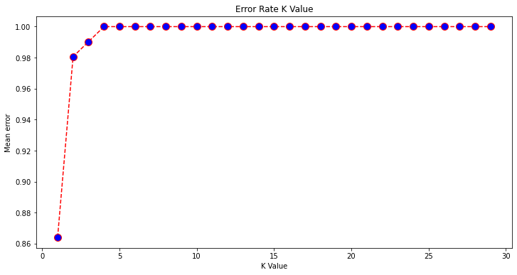

```python
plt.figure(figsize=(12,6))
plt.plot(range(1,30),error,color='red', linestyle='dashed',marker='o',markerfacecolor='blue',markersize=10)
plt.title('Error Rate K Value')
plt.xlabel('K Value')
plt.ylabel('Mean error')
```

```python
model = KNeighborsRegressor(n_neighbors=3)
model.fit(X_train, y_train)
```

```
KNeighborsRegressor(n_neighbors=3)
```

```python
y_pred = model.predict(X_test)
# performance on train data
print('Performance on training data using KNNR:',model.score(X_train,y_train))
# performance on test data
print('Performance on testing data using KNNR:',model.score(X_test,y_test))
#Evaluate the model using accuracy
acc_K=metrics.r2_score(y_test, y_pred)
print('Accuracy KNNR: ',acc_K)
```

```
Performance on training data using KNNR: 0.9269781112090636
Performance on testing data using KNNR: 0.8386246358559997
Accuracy KNNR:  0.8386246358559997
```

```python
#Store the accuracy results for each model in a dataframe for final comparison
tempResultsDf = pd.DataFrame({'Method':['KNN Regressor'], 'accuracy': [acc_K]},index={'14'})
results = pd.concat([results, tempResultsDf])
results = results[['Method', 'accuracy']]
results
```

|  | Method | accuracy |
| --- | --- | --- |
| 1 | Decision Tree | 0.838050 |
| 2 | Decision Tree k fold | 0.878652 |
| 3 | Decision Tree 2 | 0.839738 |
| 4 | Pruned Decision Tree | 0.789964 |
| 5 | Pruned Decision Tree k fold | 0.778638 |
| 6 | Random Forest Regressor | 0.789964 |
| 7 | Random Forest Regressor k fold | 0.919293 |
| 8 | Gradient Boost Regressor | 0.913861 |
| 9 | Gradient Boost Regressor k fold | 0.914866 |
| 10 | Ada Boosting Regressor | 0.812965 |
| 11 | Ada Boosting Regressor k fold | 0.824805 |
| 12 | Bagging Regressor | 0.902996 |
| 13 | Bagging Regressor k fold | 0.914942 |
| 14 | KNN Regressor | 0.838625 |

```python
kfold = KFold(n_splits=10, random_state=1)
results1 = cross_val_score(model,X, y, cv=kfold)
accuracy=np.mean(abs(results1))
print('Average accuracy: ',accuracy)
print('Standard Deviation: ',results1.std())
```

```
Average accuracy:  0.848747828315001
Standard Deviation:  0.03522861640091006
```

```python
#Store the accuracy results for each model in a dataframe for final comparison
tempResultsDf = pd.DataFrame({'Method':['KNN Regressor k fold'], 'accuracy': [accuracy]},index={'15'})
results = pd.concat([results, tempResultsDf])
results = results[['Method', 'accuracy']]
results
```

|  | Method | accuracy |
| --- | --- | --- |
| 1 | Decision Tree | 0.838050 |
| 2 | Decision Tree k fold | 0.878652 |
| 3 | Decision Tree 2 | 0.839738 |
| 4 | Pruned Decision Tree | 0.789964 |
| 5 | Pruned Decision Tree k fold | 0.778638 |
| 6 | Random Forest Regressor | 0.789964 |
| 7 | Random Forest Regressor k fold | 0.919293 |
| 8 | Gradient Boost Regressor | 0.913861 |
| 9 | Gradient Boost Regressor k fold | 0.914866 |
| 10 | Ada Boosting Regressor | 0.812965 |
| 11 | Ada Boosting Regressor k fold | 0.824805 |
| 12 | Bagging Regressor | 0.902996 |
| 13 | Bagging Regressor k fold | 0.914942 |
| 14 | KNN Regressor | 0.838625 |
| 15 | KNN Regressor k fold | 0.848748 |

### Support Vector Regressor

```python
model = SVR(kernel='linear')
model.fit(X_train, y_train)
```

```
SVR(kernel='linear')
```

```python
y_pred = model.predict(X_test)
# performance on train data
print('Performance on training data using SVR:',model.score(X_train,y_train))
# performance on test data
print('Performance on testing data using SVR:',model.score(X_test,y_test))
#Evaluate the model using accuracy
acc_S=metrics.r2_score(y_test, y_pred)
print('Accuracy SVR: ',acc_S)
```

```
Performance on training data using SVR: 0.8362014327762386
Performance on testing data using SVR: 0.8325602958914913
Accuracy SVR:  0.8325602958914913
```

```python
#Store the accuracy results for each model in a dataframe for final comparison
tempResultsDf = pd.DataFrame({'Method':['Support Vector Regressor'], 'accuracy': [acc_S]},index={'16'})
results = pd.concat([results, tempResultsDf])
results = results[['Method', 'accuracy']]
results
```

|  | Method | accuracy |
| --- | --- | --- |
| 1 | Decision Tree | 0.838050 |
| 2 | Decision Tree k fold | 0.878652 |
| 3 | Decision Tree 2 | 0.839738 |
| 4 | Pruned Decision Tree | 0.789964 |
| 5 | Pruned Decision Tree k fold | 0.778638 |
| 6 | Random Forest Regressor | 0.789964 |
| 7 | Random Forest Regressor k fold | 0.919293 |
| 8 | Gradient Boost Regressor | 0.913861 |
| 9 | Gradient Boost Regressor k fold | 0.914866 |
| 10 | Ada Boosting Regressor | 0.812965 |
| 11 | Ada Boosting Regressor k fold | 0.824805 |
| 12 | Bagging Regressor | 0.902996 |
| 13 | Bagging Regressor k fold | 0.914942 |
| 14 | KNN Regressor | 0.838625 |
| 15 | KNN Regressor k fold | 0.848748 |
| 16 | Support Vector Regressor | 0.832560 |

```python
kfold = KFold(n_splits=10, random_state=1)
results1 = cross_val_score(model,X, y, cv=kfold)
accuracy=np.mean(abs(results1))
print('Average accuracy: ',accuracy)
print('Standard Deviation: ',results1.std())
```

```
Average accuracy:  0.8256202763363282
Standard Deviation:  0.029304700201865114
```

```python
#Store the accuracy results for each model in a dataframe for final comparison
tempResultsDf = pd.DataFrame({'Method':['SVR k fold'], 'accuracy': [accuracy]},index={'17'})
results = pd.concat([results, tempResultsDf])
results = results[['Method', 'accuracy']]
results
```

|  | Method | accuracy |
| --- | --- | --- |
| 1 | Decision Tree | 0.838050 |
| 2 | Decision Tree k fold | 0.878652 |
| 3 | Decision Tree 2 | 0.839738 |
| 4 | Pruned Decision Tree | 0.789964 |
| 5 | Pruned Decision Tree k fold | 0.778638 |
| 6 | Random Forest Regressor | 0.789964 |
| 7 | Random Forest Regressor k fold | 0.919293 |
| 8 | Gradient Boost Regressor | 0.913861 |
| 9 | Gradient Boost Regressor k fold | 0.914866 |
| 10 | Ada Boosting Regressor | 0.812965 |
| 11 | Ada Boosting Regressor k fold | 0.824805 |
| 12 | Bagging Regressor | 0.902996 |
| 13 | Bagging Regressor k fold | 0.914942 |
| 14 | KNN Regressor | 0.838625 |
| 15 | KNN Regressor k fold | 0.848748 |
| 16 | Support Vector Regressor | 0.832560 |
| 17 | SVR k fold | 0.825620 |

## Tuning Hyper Parameters using RandomizedSearchCV

```python
# Hyper Paramater tuning for RandomForestRegressor

# Number of trees in random forest
n_estimators = [int(x) for x in np.linspace(start = 100, stop = 2000, num = 50)] #num = 10
#n_estimators = [int(x) for x in np.linspace(start = 100, stop = 1200, num = 12)]

# Number of features to consider at every split
max_features = ['auto', 'sqrt']

# Maximum number of levels in tree
#max_depth = [int(x) for x in np.linspace(10, 110, num = 11)]
max_depth = [int(x) for x in np.linspace(5, 30, num = 6)]
max_depth.append(None)

# Minimum number of samples required to split a node
#min_samples_split = [2, 5, 10]
min_samples_split = [2, 5, 10, 15, 100]

# Minimum number of samples required at each leaf node
#min_samples_leaf = [1, 2, 4]
min_samples_leaf = [1, 2, 5, 10]
# Method of selecting samples for training each tree
#bootstrap = [True, False]

param_grid ={
    'n_estimators': n_estimators,
    'max_features': max_features,
    'max_depth': max_depth,
    'min_samples_split': min_samples_split,
    'min_samples_leaf': min_samples_leaf,
    #'bootstrap': bootstrap
            }
```

```python
# Fitting the RandomSearchCV over the Parameter Grid to get Best Model
rdf_model=RandomForestRegressor()
randomCV = RandomizedSearchCV(rdf_model, param_distributions=param_grid, n_iter=50)
randomCV.fit(X, y)
print(randomCV.best_params_)
```

```
{'n_estimators': 1457, 'min_samples_split': 2, 'min_samples_leaf': 1, 'max_features': 'sqrt', 'max_depth': 20}
```

```python
# Printing the Mean Test Scores
randomCV.cv_results_['mean_test_score']
```

```
array([0.90394488, 0.86095428, 0.89566211, 0.90320887, 0.78160994,
       0.75576243, 0.90493636, 0.88220919, 0.78187005, 0.91006049,
       0.90075473, 0.75543524, 0.87648498, 0.90291709, 0.89346245,
       0.8609147 , 0.90852103, 0.86059213, 0.90918522, 0.87673639,
       0.89545391, 0.86904515, 0.91565729, 0.78209944, 0.90610828,
       0.91581722, 0.89582713, 0.78209582, 0.90065123, 0.89532337,
       0.92042342, 0.78094924, 0.91258391, 0.88872876, 0.90333299,
       0.89065391, 0.89583854, 0.78183137, 0.86038888, 0.90325822,
       0.78200139, 0.90962158, 0.91292766, 0.8602604 , 0.75505172,
       0.78123756, 0.91986317, 0.90481006, 0.86008227, 0.87620216])
```

```python
# Getting the Best Model suggested
best_model=randomCV.best_estimator_
best_model
```

```
RandomForestRegressor(max_depth=20, max_features='sqrt', n_estimators=1457)
```

```python
mean_test_scores=randomCV.cv_results_['mean_test_score']
mean_test_scores.sort()
print(mean_test_scores)
```

```
[0.75505172 0.75543524 0.75576243 0.78094924 0.78123756 0.78160994
 0.78183137 0.78187005 0.78200139 0.78209582 0.78209944 0.86008227
 0.8602604  0.86038888 0.86059213 0.8609147  0.86095428 0.86904515
 0.87620216 0.87648498 0.87673639 0.88220919 0.88872876 0.89065391
 0.89346245 0.89532337 0.89545391 0.89566211 0.89582713 0.89583854
 0.90065123 0.90075473 0.90291709 0.90320887 0.90325822 0.90333299
 0.90394488 0.90481006 0.90493636 0.90610828 0.90852103 0.90918522
 0.90962158 0.91006049 0.91258391 0.91292766 0.91565729 0.91581722
 0.91986317 0.92042342]
```

```python
# Using the best model to get the KFold Cross Val Score Accuracy & Std Deviation

results_rfr_RV = cross_val_score(best_model, X, y, cv=kfold)
print(results_rfr_RV)
acc_rfrRV=results_rfr_RV.mean()
std_rfrRV=results_rfr_RV.std()
print("Accuracy: %.3f%% (Std: %.3f%%)" % (results_rfr_RV.mean()*100.0, results_rfr_RV.std()*100.0))
```

```
[0.88928106 0.91797367 0.96215081 0.93938659 0.88951099 0.94052521
 0.94104839 0.92336838 0.93012651 0.9326289 ]
Accuracy: 92.660% (Std: 2.175%)
```

```python
##Store the HP Tuned results in a dataframe for final comparison
tempResultsDf = pd.DataFrame({'Method':['RandomForestRegressor(KFold)Tuned'], 'accuracy': [acc_rfrRV]},index={'18'})
results = pd.concat([results, tempResultsDf])
results = results[['Method', 'accuracy']]
results
```

|  | Method | accuracy |
| --- | --- | --- |
| 1 | Decision Tree | 0.838050 |
| 2 | Decision Tree k fold | 0.878652 |
| 3 | Decision Tree 2 | 0.839738 |
| 4 | Pruned Decision Tree | 0.789964 |
| 5 | Pruned Decision Tree k fold | 0.778638 |
| 6 | Random Forest Regressor | 0.789964 |
| 7 | Random Forest Regressor k fold | 0.919293 |
| 8 | Gradient Boost Regressor | 0.913861 |
| 9 | Gradient Boost Regressor k fold | 0.914866 |
| 10 | Ada Boosting Regressor | 0.812965 |
| 11 | Ada Boosting Regressor k fold | 0.824805 |
| 12 | Bagging Regressor | 0.902996 |
| 13 | Bagging Regressor k fold | 0.914942 |
| 14 | KNN Regressor | 0.838625 |
| 15 | KNN Regressor k fold | 0.848748 |
| 16 | Support Vector Regressor | 0.832560 |
| 17 | SVR k fold | 0.825620 |
| 18 | RandomForestRegressor(KFold)Tuned | 0.926600 |

# Hyper Parameter tuning for BaggingRegressor

```python
# HP tuning for BaggingRegressor
bgr_model1=BaggingRegressor()
```

```python
n_estimators = [int(x) for x in np.linspace(start = 10, stop = 120, num = 12)]
max_features = [3,4,5,6]
bootstrap = [True, False]
bootstrap_features = [True, False]

param_grid1 ={
    'n_estimators': n_estimators,
    'max_features': max_features,
    'bootstrap': bootstrap,
    'bootstrap_features':bootstrap_features
            }
```

```python
# Fitting the RandomSearchCV over the Parameter Grid to get Best Model
randomCV_bgr = RandomizedSearchCV(bgr_model1, param_distributions=param_grid1, n_iter=50)
randomCV_bgr.fit(X, y)
print(randomCV_bgr.best_params_)
```

```
{'n_estimators': 70, 'max_features': 6, 'bootstrap_features': False, 'bootstrap': False}
```

```python
# Printing the Mean Test Scores
randomCV_bgr.cv_results_['mean_test_score']
```

```
array([0.8457093 , 0.76822999, 0.89976145, 0.70194907, 0.85277337,
       0.74809755, 0.8568697 , 0.78178108, 0.73173127, 0.83329214,
       0.74729932, 0.73549088, 0.71169769, 0.71380848, 0.82061452,
       0.77067371, 0.74072298, 0.83963549, 0.77495354, 0.70877132,
       0.79764549, 0.87254973, 0.77939652, 0.8278927 , 0.85705216,
       0.85134315, 0.80190308, 0.80939799, 0.74675591, 0.8038513 ,
       0.65912045, 0.84774138, 0.73537161, 0.86634307, 0.71291057,
       0.78299697, 0.84957308, 0.8203061 , 0.78120799, 0.89560918,
       0.89730689, 0.7468678 , 0.80735635, 0.67450176, 0.69616051,
       0.6462297 , 0.72767388, 0.85309261, 0.79227463, 0.70122716])
```

```python
# Getting the best model from Random search CV
best_model_bgr=randomCV_bgr.best_estimator_
best_model_bgr
```

```
BaggingRegressor(bootstrap=False, max_features=6, n_estimators=70)
```

```python
# Using the best model to get the KFold Cross Val Score Accuracy & Std Deviation
results_best_bgr = cross_val_score(best_model_bgr, X, y, cv=kfold)
print(results_best_bgr)
acc_best_bgr=results_best_bgr.mean()
std_best_bgr=results_best_bgr.std()
print("Accuracy: %.3f%% (Std: %.3f%%)" % (results_best_bgr.mean()*100.0, results_best_bgr.std()*100.0))
```

```
[0.86927146 0.91379627 0.95721442 0.91830067 0.86845524 0.93520119
 0.90904273 0.92050332 0.91612295 0.91534721]
Accuracy: 91.233% (Std: 2.541%)
```

```python
tempResultsDf = pd.DataFrame({'Method':['BaggingRegressor(KFold)Tuned'], 'accuracy': [acc_best_bgr]},index={'18'})
results = pd.concat([results, tempResultsDf])
results = results[['Method', 'accuracy']]
results
```

|  | Method | accuracy |
| --- | --- | --- |
| 1 | Decision Tree | 0.838050 |
| 2 | Decision Tree k fold | 0.878652 |
| 3 | Decision Tree 2 | 0.839738 |
| 4 | Pruned Decision Tree | 0.789964 |
| 5 | Pruned Decision Tree k fold | 0.778638 |
| 6 | Random Forest Regressor | 0.789964 |
| 7 | Random Forest Regressor k fold | 0.919293 |
| 8 | Gradient Boost Regressor | 0.913861 |
| 9 | Gradient Boost Regressor k fold | 0.914866 |
| 10 | Ada Boosting Regressor | 0.812965 |
| 11 | Ada Boosting Regressor k fold | 0.824805 |
| 12 | Bagging Regressor | 0.902996 |
| 13 | Bagging Regressor k fold | 0.914942 |
| 14 | KNN Regressor | 0.838625 |
| 15 | KNN Regressor k fold | 0.848748 |
| 16 | Support Vector Regressor | 0.832560 |
| 17 | SVR k fold | 0.825620 |
| 18 | RandomForestRegressor(KFold)Tuned | 0.926600 |
| 18 | BaggingRegressor(KFold)Tuned | 0.912326 |

### Observation:

After Hyper Parameeter Tuning, RandomForestRegressor remains the best algorithm, in terms of Accuracy at 92.66%.